# Project 3

#### Dataset 2 (Other Text responses)

Free form responses for those who selected the other option in the main multiple choice survey.

Data

```r
Data2 <- dbGetQuery(my_connection,"Select * FROM dbo.other_text_responses")
```

Filtering out non-data roles We are only going to look at respondents primary responsibilities presumably entail working with data on a daily basis, given their titles.

```r
DataRoles <- dbGetQuery(my_connection,"Select *
           FROM dbo.other_text_responses
           WHERE
           [Q5_OTHER_TEXT] like '%Data%' OR
           [Q5_OTHER_TEXT] like '%Machine     Learning%'
OR [Q5_OTHER_TEXT] like   '%Artifical Intelligence%' OR [Q5_OTHER_TEXT] like '%Business Intelligence%'
OR  [Q5_OTHER_TEXT] like '%Analytics%'
OR  [Q5_OTHER_TEXT] like '%Algorithm%'
OR  [Q5_OTHER_TEXT] like '%Analyst%'
OR  [Q5_OTHER_TEXT] like '%Developer%'
OR  [Q5_OTHER_TEXT] like '%AI%'
OR  [Q5_OTHER_TEXT] like '%Programmer%'
OR  [Q5_OTHER_TEXT] like '%Math%'")
DataRoles
```

| Q12_OTHER_TEXT | Q13_OTHER_TEXT | Q14_OTHER_TEXT | Q14_Part_1_TEXT | Q14_Part_2_TEXT | Q14_Part_3_TEXT | Q14_Part_4_TEXT | Q14_Part_5_TEXT | Q16_OTHER_TEXT | Q17_OTHER_TEXT | Q18_OTHER_TEXT | Q19_OTHER_TEXT | Q20_OTHER_TEXT | Q21_OTHER_TEXT | Q24_OTHER_TEXT | Q25_OTHER_TEXT | Q26_OTHER_TEXT | Q27_OTHER_TEXT | Q28_OTHER_TEXT | Q29_OTHER_TEXT | Q2_OTHER_TEXT | Q30_OTHER_TEXT | Q31_OTHER_TEXT | Q32_OTHER_TEXT | Q33_OTHER_TEXT | Q34_OTHER_TEXT | Q5_OTHER_TEXT | Q9_OTHER_TEXT |
| --- | --- | --- | --- | --- | --- | --- | --- | --- | --- | --- | --- | --- | --- | --- | --- | --- | --- | --- | --- | --- | --- | --- | --- | --- | --- | --- | --- |
|  |  |  |  |  |  |  | Google App Scripts and App Maker | Google App Maker and Google Chrome Dev panel |  |  |  |  |  |  |  |  |  |  |  |  |  |  |  |  |  | Developer |  |
| Books |  |  |  | SPSS |  |  |  |  |  |  |  |  |  |  |  |  |  |  |  |  |  |  |  |  |  | Software Developer |  |
|  |  |  |  |  |  |  |  |  |  |  |  |  |  |  |  |  |  |  |  |  |  |  |  |  |  | Data Science Instructor |  |
|  |  |  | Microsoft Excel |  |  |  |  |  | DigitalOcean |  |  |  |  |  |  |  |  |  | DigitalOcean |  | DigitalOcean |  |  |  |  | Schedule Analyst |  |
|  |  |  |  |  | Tableau |  |  |  |  |  |  | Tableau |  |  |  |  |  |  |  |  |  |  |  |  |  | Manager of Analytics |  |
|  |  |  |  |  |  | Jupyterlab on google cloud |  |  |  | rust |  |  |  |  |  |  |  |  |  |  |  |  |  |  |  | Data Architect |  |
|  |  |  | Excel |  |  |  |  |  |  |  |  |  |  |  |  |  |  |  |  |  |  |  |  |  |  | Financial Data Analyst |  |
|  |  |  |  |  |  | Python |  |  |  |  |  |  |  |  |  |  |  |  |  |  |  |  |  |  |  | Business Intelligence Manager |  |
|  |  |  | Excel |  |  |  |  |  |  |  |  |  |  |  |  |  |  |  |  |  |  |  |  |  |  | Marketing Analytics Manager |  |
|  |  |  |  |  |  | r studio |  |  |  |  |  |  |  |  |  |  |  |  |  |  |  |  |  |  |  | data officer |  |

[output cut: 213 more lines]

#### Primary Tool

The survey question where a significant amount of respondents picked the other option is Question 14 (What is the primary tool that you use at work or school to analyze data? (Include text response) - Selected Choice). Therefore, we would like to see if there are any other skillsets or tools here that are worth looking into besides the ones mentioned in the main dataset.

```r
PrimaryTool <- DataRoles %>%
  select("Q14_OTHER_TEXT")

PrimaryTool <-PrimaryTool %>%
  gather(Q14other,response)  %>%
    group_by(response) %>%
      summarize(count_reponse = n())
PrimaryTool
```

| response | count_reponse |
| --- | --- |
|  | 206 |
| All of the above -- depending on the business problem/dataset/solution | 1 |
| Both Local and Cloud-based | 1 |
| C# | 1 |
| Excel, adobe analytics, Google sheets | 1 |
| Jupyter note | 1 |
| Local developments & Cloud-based data software & APIs | 1 |
| Not sure | 1 |
| Not using at work or school | 1 |
| Octave, python notebooks etc. | 1 |

[output cut: 8 more lines]

Respondents were allowed to input more than one answer in this field,i.e. one respondent can list multiple tools in their response, usually separated by a comma. We will therefore split the responses into separate columns first and then convert the dataset from wide to long.

```r
PrimaryTool <- separate(PrimaryTool,response,
         into=c("T1","T2","T3"),
         sep=",")
PrimaryTool %>% gather(Tool,Response,
        T1,T2,T3)%>% group_by(Response)%>%
  summarize(Sum_response=sum(count_reponse))
```

| Response | Sum_response |
| --- | --- |
|  | 206 |
| adobe analytics | 1 |
| Google sheets | 1 |
| python | 1 |
| Python | 1 |
| python notebooks etc. | 1 |
| Pytorch | 1 |
| R - not a production user of deep learing | 1 |
| All of the above -- depending on the business problem/dataset/solution | 1 |
| Both Local and Cloud-based | 1 |

[output cut: 17 more lines]

Looks like Python might be the winner here.

## Indeed Scrape

We performed multiple web-scrapes of Indeed.com to collect data on real-world examples of jobs with the title “data scientist.” These data were intended to give further insight into the expectations of the market such as where data scientists’ jobs are located and the salaries. Thus, we looked for those markers of job title, company, salary ranges and location of each posting.

Our initial scrape was compiled to create a sample for analysis. In this, we only wanted to create a data frame with the job title from the first page of results in the Indeed job search. A regular expression in conjunction with functions from the rvest package allowed the information to be extracted from the html of the webpage. The first scraping example is displayed below.

```r
url <- 'https://www.indeed.com/jobs?q=data%20scientist&l&vjk=00ba1a22ba67ffd2'
webpage <- read_html(url)
job_data_html <- html_nodes(webpage,'.jobtitle , #sja0 b')
job_data <- html_text(job_data_html)
head(job_data)
```

```
## [1] "\nIntern - Data Scientist - Summer 2021"
## [2] "Data"
## [3] "Scientist"
## [4] "\nSenior Data analyst (REMOTE)"
## [5] "\nData Scientist"
## [6] "\nData Scientist"
```

In each case, the data was extracted as a text file and was rife with errors. It was not usable at this stage. Another parameter was necessary to clean the data and transform it into something functional. In this case, we decided a vector of characters would suffice. The example of the regular expression used to extract the job title of each posting on the first webpage of Indeed for this singular sample is shown.

```r
str_extract(job_data, "(\\w+.+)+")
```

We found this string to be the most effective at parsing the job title of all listing on the first page into usable form. We repeated this process until we had a clear understanding of each variable of interest to us available on the webpage.

Some information presented challenges that were not transforming data types or parsing strings but rather developing a standard quantifiable value from a range of numbers in different units and categories. A good example of this is the monetary information where the employers listed the information as a range of values per year, per hour, and contractual amounts. None of which would be remotely close when performing calculations.

To solve this, we separated the information we had into categories and selected the category with the most results. Those with a salary listed as a range per year had the highest proportion of jobs with any monetary information on its posting. The process of cleaning can be seen here:

```r
# Performing the 1-page scrape and producing a text file from the html of indeed.com
url <- 'https://www.indeed.com/jobs?q=data%20scientist&l&vjk=00ba1a22ba67ffd2'
webpage <- read_html(url)
sal_data_html <- html_nodes(webpage,'.salaryText')
sal_data <- html_text
# Cleaning the subset begins with evaluation of the data
head(sal_data)
# Extracting the salary ranges provided as characters
salary_data <- str_extract(job_data, "(\\w+.+)+")
# Removing the hourly rates - a smaller group than salary range
salary_data <- str_remove_all(salary_data, "\\d+ an hour")
# Remove the label " a year" since all should be at this stage
salary_data <- str_remove_all(salary_data, " a year")
# Remove the dollar sign - they are all dollars
salary_data <- str_remove_all(salary_data,"\\$")
# Anticipating duplicates - testing a solution
salary_data <- as.data.frame(salary_data)
salary_data[2,1] <- ("70,000 - $90,000")
salary_data %>%
  mutate(salary = as.factor(job_data)) %>%
  count(salary)
```

As with all samples, there were missing values inherent to the postings on Indeed. Salary information was no exception. These missing values were included in the dataset but were not included in the analysis. To determine how well these chunks of code ran with the full data from the indeed search, we ran it in for-loops to collect pages of job information.

This creates a data frame of the publicly posted jobs with the title “data scientist” on Indeed on October 13, 2020 called *Indeed*. It contains several attributes of the posted jobs, namely, the job title, the company name or employer, location, job summary, and a link to the original posting webpage. Data is then exported as a spreadsheet (.csv) and uploaded to our GitHub repository to make it more accessible and reproducible.

### Indeed Analysis

The code above results in the CSV stored in our Github repository, which we’ll read into a dataframe.

```r
indeed_df <- read.csv(url("https://raw.githubusercontent.com/Lnkiim/DATA607_project3/main/Indeed.csv"), stringsAsFactors=FALSE)
indeed_df$minsal <- str_remove(indeed_df$minsal, "[,]")
indeed_df$minsal <- as.numeric(as.character(indeed_df$minsal))
indeed_df$maxsal <- str_remove(indeed_df$maxsal, "[,]")
indeed_df$maxsal <- as.numeric(as.character(indeed_df$maxsal))
glimpse(indeed_df)
```

```
## Rows: 1,412
## Columns: 10
## $ X        <int> 1, 2, 3, 4, 5, 6, 7, 8, 9, 10, 11, 12, 13, 14, 15, 16, 17,...
## $ title    <chr> "Senior Data Scientist", "Data Scientist", "Clinical Data ...
## $ date     <chr> "Today", "Just posted", "30", "8", "30", "Just posted", "3...
## $ company  <chr> "Headcheckit.com", "Alto Neuroscience, Inc", "Nucleus", "C...
## $ salary   <chr> "112,853 - 204,864", "70,000 - 90,000", "81,078 - 129,709"...
## $ maxsal   <dbl> 204864, 90000, 129709, NA, 177616, NA, NA, 204864, 90000, ...
## $ minsal   <dbl> 112853, 70000, 81078, NA, 70000, NA, NA, 112853, 70000, 81...
## $ location <chr> NA, "San Francisco Bay Area, CA", "Glen Allen, VA", "Hernd...
## $ summary  <chr> "Being part of a team of data scientists.", "This person w...
## $ link     <chr> "https://www.indeed.com/company/Headcheckit.com/jobs/Senio...
```

```r
indeed_toploc <- count(indeed_df, location, sort=TRUE)
indeed_toploc <- (top_n(indeed_toploc, 20))
indeed_toploc <- indeed_toploc %>%
  filter(rank(desc(n))<=50)

kable(indeed_toploc, format = "markdown")
```

| location | n |
| --- | --- |
| Washington, DC | 155 |
| NA | 139 |
| Lexington Park, MD | 93 |
| Atlanta, GA | 91 |
| Charlottesville, VA | 91 |
| Plano, TX | 90 |
| South Lake, CA | 84 |
| Hershey, PA | 83 |
| Sunnyvale, CA | 77 |
| Herndon, VA | 74 |
| New York, NY | 71 |
| Mossville, IL | 70 |
| Portland, OR | 59 |
| San Francisco Bay Area, CA | 59 |
| Salt Lake City, UT | 55 |
| Arlington, VA | 32 |
| Glen Allen, VA | 20 |
| Glastonbury, CT | 12 |
| Norwood, MA | 10 |
| Louis, MO | 6 |

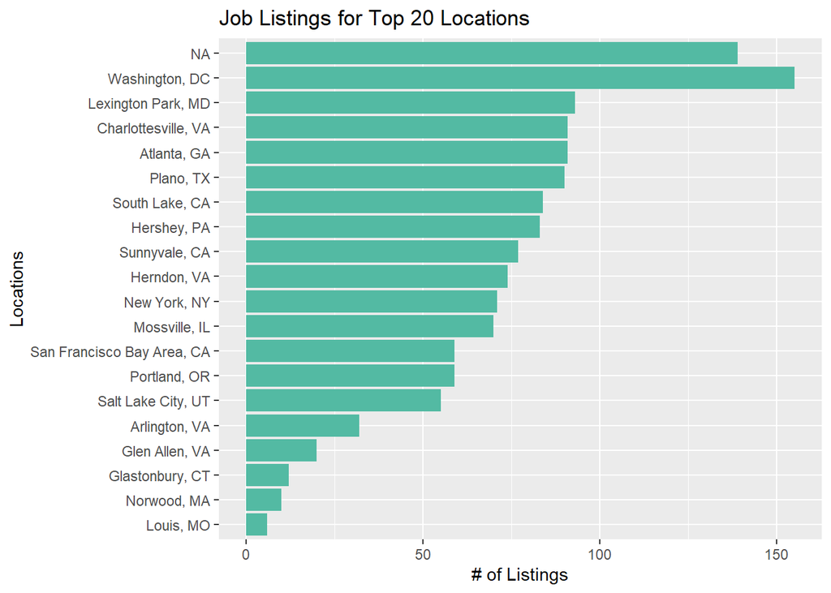

```r
indeed_toploc$location <- factor(indeed_toploc$location, levels = indeed_toploc$location[order(indeed_toploc$n)])

ggplot(indeed_toploc, aes(x = n, y = location, fill = n)) +
  geom_bar(stat="identity", fill="#53baa3") +
  labs(title="Job Listings for Top 20 Locations") +
  xlab('# of Listings') +
  ylab('Locations')
```

Taking a closer look, we see that for DC the postings primarily come from the CIA and the US Dept of the Treasury. All of the Lexington Park, MD postings are from the KBR. This is just a point-in-time snapshot of the job listings at the time of the scrape (during a strange economic time as well) - but it seems fair to conclude that in general the largest quantity of ‘Data Science’ jobs are available on the East Coast - one could say that proximity to a urban center is a desirable attribute for a data scientist, as that is where the work seems to be!

```r
indeed_dc <- subset(indeed_df, (location == "Washington, DC"))
indeed_topdc <- count(indeed_dc, company, sort=TRUE)
kable(top_n(indeed_topdc, 15), format = "markdown")
```

| company | n |
| --- | --- |
| Central Intelligence Agency | 91 |
| US Department of the Treasury | 50 |
| Clarity Campaign Labs | 11 |
| Wallethub | 2 |
| Perspecta | 1 |

```r
indeed_lex <- subset(indeed_df, (location == "Lexington Park, MD"))
indeed_toplex <- count(indeed_lex, company, sort=TRUE)
kable(top_n(indeed_toplex, 15), format = "markdown")
```

| company | n |
| --- | --- |
| KBR | 93 |

Finally, looking at the salary ranges, where they were available, we see that the mean minimum on the salary range is $83,578 and the mean maximum is $139,151. Further, the mean range of the salary is $55,623 - which is also plotted. While there are certainly many missing values, it is interesting to see the variation in the salary range offered from this Indeed scrape.

```r
mean(indeed_df$minsal, na.rm=TRUE)
```

```
## [1] 83578.25
```

```r
mean(indeed_df$maxsal, na.rm=TRUE)
```

```
## [1] 139151.1
```

```r
indeed_df <- indeed_df %>%
  mutate(indeed_df, sal_range = maxsal - minsal)

mean(indeed_df$sal_range, na.rm=TRUE)
```

```
## [1] 55622.74
```

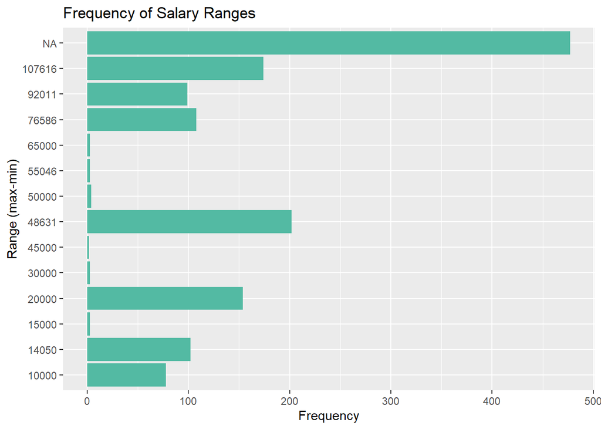

```r
ggplot(indeed_df, aes(x = factor(sal_range), fill = sal_range)) +
  geom_bar(fill="#53baa3") +
  coord_flip() +
  labs(title="Frequency of Salary Ranges") +
  xlab('Range (max-min)') +
  ylab('Frequency')
```

## Glassdoor Text Analysis

In this analysis we used several functions to compute the most frequently occurring words in the data set. The data came from jobs posted on Glassdoor that were scraped into a text file on August 1, 2020. Our goal was to determine if there were any traits or trends that a data scientist would need. To do so, we narrowed our search down to those skills generally thought to be desirable traits of a data scientist based on what we understood as existing norms. This led to an extraction process that gave us the tools, technical skills, and soft skills present in the posting of data science positions for that point in time.

Ideally, the extracted information would be able to tell us what recruiters are looking for and what applicants should have already mastered. Technical skills could be more relevant to express skills related to machine learning and math. Soft skills are relevant to interpersonal behavior.

```r
# Reading in data
gd_url="https://raw.githubusercontent.com/Lnkiim/DATA607_project3/main/glassdoor_ds_jobs.csv"
gd_df <- read_csv(url(gd_url))
```

#### Word Counts

As a first iteration of the analysis, we looked at the most frequently occuring words across all job descriptions. Notice in the code, that we anti_join with ‘stop words’. ‘Stop words’ are lexicons that are commonly occuring words that are usually functional in syntax but provide little content (eg: in, the, who, was). This will make our dataset smaller and more compliant for further manipulation.

```r
gd_df <-
  gd_df %>%
    mutate(job_id = row_number())

tidy_gd_df <- gd_df %>%
  unnest_tokens(word, Summary)

# remove words that don't mean much
tidy_gd_df <- tidy_gd_df %>%
  anti_join( stop_words, by="word")

# tells you most frequently occuring words across all job descriptions

global_word_count <-
  tidy_gd_df %>%
    count(word, sort = TRUE)

global_word_count %>%
  head(15)
```

| word | n |
| --- | --- |
| data | 17145 |
| experience | 7693 |
| business | 3997 |
| team | 3380 |
| science | 3084 |
| learning | 3041 |
| skills | 2870 |
| analytics | 2734 |
| analysis | 2395 |
| machine | 2174 |

[output cut: 5 more lines]

#### Wordcloud

The wordcloud below nicely visualizes the most frequently occurring words. The most frequently used words are relevant to describe the data science industry as a whole. However, there isn’t much insight we can glean about the most desirable traits of a data scientist just from a simple count.

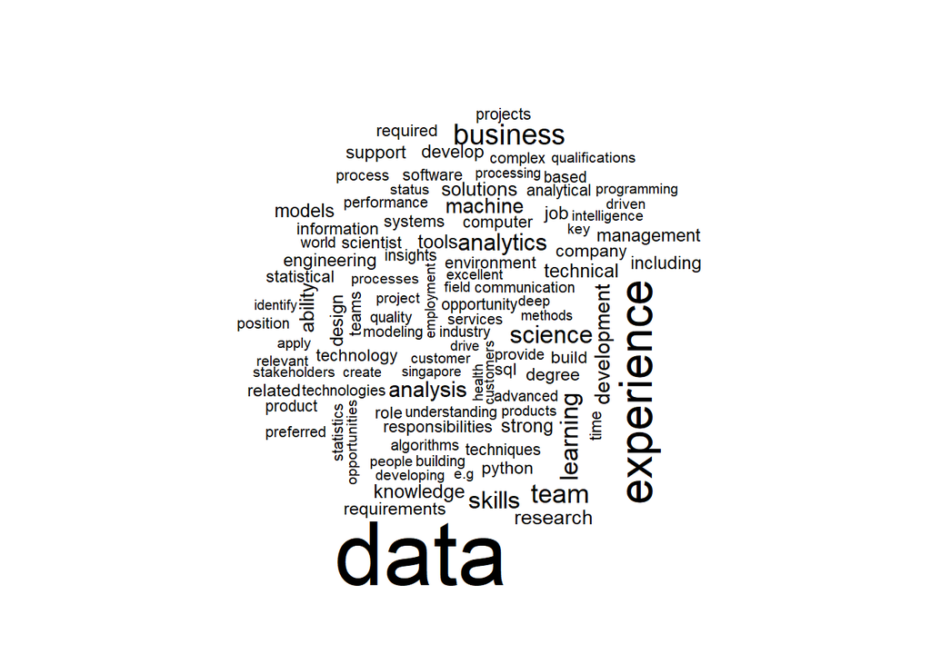

```r
# Words must have occured in the dataset at least 100 times.

tidy_gd_df %>%
  anti_join(stop_words) %>%
  count(word) %>%
  with(wordcloud(word, n, max.words = 100))
```

#### In-demand Skills

Our methodology was to observe the most frequently occurring words in the job descriptions of each posting. This is appropriate because tools are usually named as single words which indicate hard skills demanded by the potential employer. We start by curating a list of technical skills and see how frequently these words appear in our Glassdoor job description dataset. Instead of scraping a list of technical skills/tools from scratch, we started with some tools that appeared in the Kaggle Survey dataset. After analyzing the results with just the tools that appeared in the Kaggle survey, we found that the data was sparse and hypothesized that the list of technical skills was not inclusive enough to capture the story behind the Glassdoor dataset. Hence, we manually entered more frequently used engineering tools and got better results.

```r
# reading raw csv but probably more ideal to bring data from database
url_mult_response="https://raw.githubusercontent.com/Lnkiim/DATA607_project3/main/multiple_choice_responses_2.csv"
mult_response_df <- read_csv(url(url_mult_response))
# create dataframe just for question 18
q_18 <- mult_response_df %>%
  select(starts_with("Q18"))
# get rid of row 1 bc it has the question
q_18 <- q_18[-1,]

prog_languages <-
  q_18 %>%
    gather(key="question", value="response")  %>%
      group_by(response) %>%
        summarize(count_reponse = n()) %>%
          arrange(desc(response)) %>%
            head(12)
prog_languages_list <- tolower(prog_languages$response)

q_16 <- mult_response_df %>%
  select(starts_with("Q16"))

# get rid of row 1 bc it has the question
q_16 <- q_16[-1,]

dev_env <-
  q_16 %>%
      gather(key="question", value="response")  %>%
        group_by(response) %>%
          summarize(count_reponse = n()) %>%
            arrange(desc(response)) %>%
              head(12)
```

```r
dev_env_list <- tolower(dev_env$response)

clean_devEnvList <- c()

# clean list of development environment tools
for (text in dev_env_list) {
  devList <- strsplit(text, "[/(),]")
  for (item in devList) {
    clean_devEnvList <- c(clean_devEnvList,item)
  }
}

# adding more tools that dataset might not include
my_list <- c("git", "github", "sublime", "sublime text", "docker", "command line", "php", "intellij", "intellij idea", "slack", "gitlab", "iterm", "iterm2", "pycharm", "unity", "jetbrains", "linux", "postman", "api","sas", "apache","spark", "apache spark", "bigml", "excel", "ggplot", "ggpolt2", "tableau", "hadoop", "scikit", "scikitlearn" ,"scikit learn", "tensorflow", "sas","json", "xml", "")

technical_traits <- c(prog_languages_list,clean_devEnvList,my_list )
technical_traits <- trimws(technical_traits, which = c("both"))

# Global Words that intersect with list of scraped technical traits
technical_skills <- tidy_gd_df %>%
  filter(word %in% technical_traits)

technical_word_count <-
  technical_skills %>%
    count(word, sort = TRUE)

technical_word_count
```

| word | n |
| --- | --- |
| python | 1426 |
| sql | 1181 |
| spark | 532 |
| tableau | 482 |
| hadoop | 394 |
| java | 391 |
| excel | 313 |
| sas | 247 |
| tensorflow | 208 |
| linux | 151 |

[output cut: 20 more lines]

#### Technical Wordcloud

We can see from the Wordcloud and the data frame, Python and SQL are the most sought after technical skills by a significant margin. The second and third sought more frequently sought after tools include Spark and Tableau but the large gap between the top two and the next two, suggests that there are technical skills which may not be single word tools. We investigated further in more advanced natural language processing frameworks.

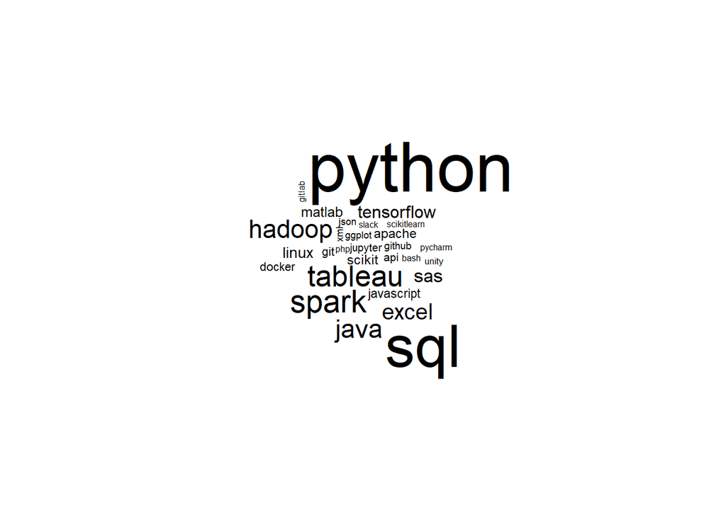

```r
technical_skills %>%
  count(word) %>%
  with(wordcloud(word, n))
```

#### TF and TF-IDF

In the previous section we looked at which words were mentioned the most frequently across all job descriptions on Glassdoor. In this section, we investigated which traits of a data scientist were most desirable by term frequency. Term frequency here is defined a little differently than a global word count because this calculation is grouped by ‘document’ (which in our use case is a company). This means that the frequency of a word takes into account how many times a word was mentioned relative to the total word count of the company. Next we looked at TF-IDF which is another way of evaluating if a word is significant. Previously we looked at popular words, with tf-idf, we are looking to measure the rarity of a word. Oftentimes, uniquely used words will give us some insight about the entire document, more than the most popular word.

```r
# grouped so that each company is a "document" and each word is a "token"
term_freq <- tidy_gd_df %>%
  anti_join( stop_words, by="word") %>%
    group_by(`Company Name`) %>%
      count(word, sort = TRUE)

term_freq <-
  term_freq %>%
    mutate(tot_word_count = sum(n))

term_freq_by_rank <- term_freq %>%
  mutate(rank = row_number(),
         term_freq = n/tot_word_count)

# bind_tf_idf
term_freq_by_rank <-
  term_freq_by_rank %>%
    bind_tf_idf(word, `Company Name`, n) %>%
    arrange(desc(tf_idf))

term_freq_by_rank
```

| Company Name | word | n | tot_word_count | rank | term_freq | tf | idf | tf_idf |
| --- | --- | --- | --- | --- | --- | --- | --- | --- |
| MILLENNIUM CAPITAL MANAGEMENT (SINGAPORE) PTE. LTD. | arbitrage | 3 | 45 | 1 | 0.066666667 | 0.066666667 | 6.8090393 | 0.45393595 |
| Samsung Electronics\r3.6 | scm | 11 | 169 | 1 | 0.065088757 | 0.065088757 | 6.8090393 | 0.44319191 |
| CultureFit Technology Staffing\r5.0 |  | 18 | 245 | 1 | 0.073469388 | 0.073469388 | 5.7104270 | 0.41954158 |
| JobsLab |  | 12 | 195 | 1 | 0.061538462 | 0.061538462 | 6.8090393 | 0.41901780 |
| DSW\r3.3 | designer | 7 | 98 | 2 | 0.071428571 | 0.071428571 | 5.1996014 | 0.37140010 |
| Novacom Technologies | banking | 2 | 17 | 1 | 0.117647059 | 0.117647059 | 3.0248497 | 0.35586467 |
| StraitSys\r4.4 | straitsys | 11 | 229 | 1 | 0.048034934 | 0.048034934 | 6.8090393 | 0.32707176 |
| Farmer's Business Network, Inc.\r3.6 | farmers | 15 | 239 | 1 | 0.062761506 | 0.062761506 | 5.1996014 | 0.32633482 |
| Idealab\r4.0 |  | 25 | 444 | 2 | 0.056306306 | 0.056306306 | 5.7104270 | 0.32153305 |
| Zoba | zoba | 9 | 200 | 2 | 0.045000000 | 0.045000000 | 6.8090393 | 0.30640677 |

[output cut: 9990 more lines]

Unfortunately, the tf-idf doesn’t give us much helpful additional insight in discovering which traits make a most desirable data scientist. However, it does show us that the top words are jargon specific to a specialized industry. (eg: arbitrage, banking, scm).

#### N-gram Analysis

As mentioned, it is reasonable to search for tools with a global count because tools are often single words. However, soft skills and technical skills may be expressed more frequently with two words, or perhaps even three words. In this section we look at n_grams, which is an investigation as to how often n number of words occur together.

```r
subset_gd_df <- gd_df[,c(3,5)]

# common pairs of words
gd_bigrams <- subset_gd_df  %>%
  unnest_tokens(bigram, Summary, token = "ngrams", n = 2)

bigrams_separated <- gd_bigrams %>%
  separate(bigram, c("word1", "word2"), sep = " ")

bigrams_separated <- bigrams_separated %>%
  filter(!word1 %in% stop_words$word) %>%
  filter(!word2 %in% stop_words$word)

bigram_counts <- bigrams_separated %>%
  count(word1, word2, sort = TRUE)
```

Here we can see that the most frequently occuring couplings of words do illustrate the most sought after technical and soft skills. Let us use the visual below to investigate further.

```r
bigram_counts
```

| word1 | word2 | n |
| --- | --- | --- |
| machine | learning | 2113 |
| data | science | 1761 |
| data | scientist | 924 |
| computer | science | 906 |
| data | analytics | 607 |
| communication | skills | 573 |
| data | analysis | 550 |
| data | sets | 473 |
| equal | opportunity | 465 |
| data | mining | 430 |

[output cut: 9990 more lines]

Here we’re able to visualize the relationship between couplings of words. The darkness of the arrow expresses how strong the relationship between two words is, and the arrow indicates the direction of the relationship. Using n-grams when n equals 2 lists a lot of technical skills, some of which include: ‘machine learning’, ‘data analytics’, ‘communication skills’, ‘data mining’,‘deep learning’.

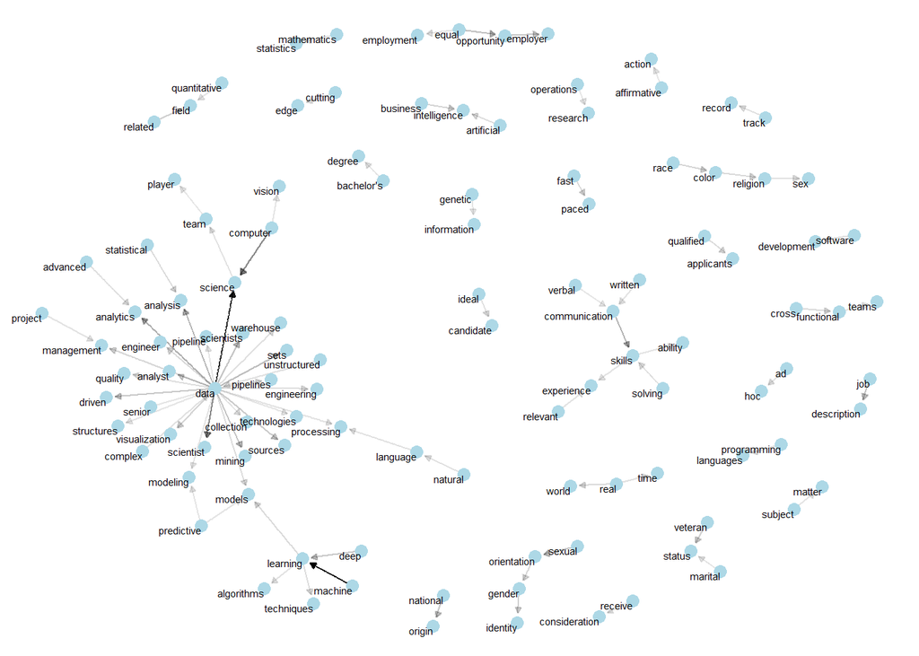

```r
set.seed(2022)

bigram_graph <- bigram_counts %>%
  filter(n > 120) %>%
  graph_from_data_frame()


a <- grid::arrow(type = "closed", length = unit(.05, "inches"))

ggraph(bigram_graph, layout = "fr") +
  geom_edge_link(aes(edge_alpha = n), show.legend = FALSE,
                 arrow = a, end_cap = circle(.07, 'inches')) +
  geom_node_point(color = "lightblue", size = 3) +
  geom_node_text(aes(label = name), vjust = 1, hjust = 1, size=2) +
  theme_void()
```

Looking at n-grams where n equals three shows us many more soft skills that are sought after. Some of the most sought after soft skills include: written communication skills, fast paced environment, cross functional teams, verbal communication skills, agile software development, and strong analytical skills.

```r
# common 3 words

gd_trigrams <- subset_gd_df  %>%
  unnest_tokens(trigram, Summary, token = "ngrams", n = 3)

gd_trigrams_separated <- gd_trigrams %>%
  separate(trigram, c("word1", "word2", "word3"), sep = " ")

trigrams_separated <- gd_trigrams_separated %>%
  filter(!word1 %in% stop_words$word) %>%
  filter(!word2 %in% stop_words$word) %>%
  filter(!word3 %in% stop_words$word)

trigrams_counts <- trigrams_separated %>%
  count(word1, word2,word3, sort = TRUE)

trigrams_counts
```

| word1 | word2 | word3 | n |
| --- | --- | --- | --- |
| equal | opportunity | employer | 355 |
| sexual | orientation | gender | 232 |
| race | color | religion | 211 |
| orientation | gender | identity | 205 |
| machine | learning | models | 189 |
| natural | language | processing | 172 |
| machine | learning | techniques | 168 |
| data | science | team | 149 |
| color | religion | sex | 144 |
| machine | learning | algorithms | 132 |

[output cut: 9990 more lines]

# Conclusion

It is interesting to see that as we write this report in R, the most in-demand language for data science and machine learning appears to be Python from both the Glassdoor and Kaggle analyses. This was closely followed by SQL with both languages maintaining a strong lead. With Python being the most frequently used language, it is a natural progression to see Matplotlib as the most frequently used visualization tool. It comes as no surprise that the other tools for machine learning frameworks, linear regressions, and modeling are also based on working with the Python programming language. This is easily the most notable hard skill and tool demanded from the programming portion of what data scientists do; but it is not the only skill.

Soft skills, elucidated by the tables and clusters of words displayed in the Glassdoor analysis, gives another look into what these positions require. We found that having experience, especially in data, was another high priority. Employers are interested in individuals who can work well in teams and above all, possess some business knowledge. These word clouds added to more hard skills for an aspiring data scientist to learn Spark and Tableau.

There is no clear choice in the data science community when it comes to selecting cloud platforms. The top 3 in use, according to the Kaggle survey analysis were: Amazon’s AWS, Google’s Cloud, and Microsoft Azure. Although it is important to note that many people did not respond to this at all, which could mean those respondents are using multiple or no cloud platforms. Regardless, selecting one of those main three would be a good place to start for aspiring data scientists.

Importantly, we are living in an unprecedented time. A pandemic has rearranged and continues rearrange company dynamics as we adapt to a new lifestyle across the world. We have no doubt that these changes have influenced the data.

For us, this project was meant to teach us how to collaborate on a project of this size, work with messy data, and learn a bit more about the field we all are entering. It felt a bit like peeling back the layers of an onion, seeing each other’s code and findings made us pose more questions and think of new directions to pursue. So much data, so little time. We hope the analysis above gives others some preliminary insight into the demands and expectations of the data science field, and prompts readers to peel back another layer of the onion.

## Sources

Gan, James. “Various Data Science Titled Jobs in Singapore 2020.” Kaggle, 16 Aug. 2020, www.kaggle.com/jamesgsw/various-data-science-titled-jobs-in-singapore-2020/metadata.

Human Resources, University of Pennsylvania. “What’s Driving the Demand for Data Scientists?” Knowledge@Wharton, 8 Mar. 2019, knowledge.wharton.upenn.edu/article/whats-driving-demand-data-scientist

Milan. “GlassDoor(Data Scientist).” Kaggle, 1 Aug. 2020, www.kaggle.com/milan400/glassdoordata-scientist.

Palmore, Zach. “Indeed.csv” Data Scientist Jobs, Employment | Indeed.com, 13 Oct. 2020, www.indeed.com/jobs?q=data+scientist%5C.

## Contributors

> Douglas Barley: database storage, Kaggle Survey tidying, presenter

> Atina Karim: database storage, Kaggle Survey analysis, lead presenter

> Rachel Greenlee: project manager, Indeed analysis, graphing support, writing support

> Ellen Kim: github master, Glassdoor tidying and analysis, presenter

> Zachary Palmore: Indeed scrape, Indeed tidying, lead project writer